# Slalom Data Challenge

*Jeffrey Box* 10-29-18

Please see the readme.md for comprehensive information about this model

**Objectives:**

- Identify the top predictors of hourly sales ('deliverable_1_top_predictors.csv')
- Predict total sales revenue for all 14 stores on 2017-07-15 during hour 12, assuming a clear day and average temperature of 86 degrees ('deliverable_2_store_predictions.csv')

**Resources:** SalesbyHour.CSV

**Overview:**

1. Load
2. Prepare
3. Understand
4. Model
5. Train
6. Predict

## BEFORE YOU START

This project requires Python 3.6, Jupyter, and various Python libraries. Please ensure you are properly setup: In your shell, 1) navigate to the resources folder provided, 2) create a new python environment from my requirements file, 3) and then activate. 4) Change the directory to deliverables, and then 5) start Jupyter.

1. $ cd … /Slalom/Resources
2. $ conda env create --file slalom_env_setup.txt
3. $ source activate slalom
4. $ cd ../Deliverables
5. $ jupyter notebook

## INTRODUCTION

**Business Case**

- The executive team of a quick service restaurant is interested in leveraging advanced analytics to gain insight into store performance and revenue drivers.
- Using historical data, I will identify the top predictors of hourly sales and predict total sales revenue for all 14 stores on 2017-07-15 during hour 12, assuming a clear day and average temperature of 86 degrees.

**Objectives**

1. Identify the top predictors of hourly sales ('deliverable_1_top_predictors.csv')
2. Predict total sales revenue for all 14 stores on 2017-07-15 during hour 12, assuming a clear day and average temperature of 86 degrees('deliverable_2_store_predictions.csv')

**Resources**

- SalesbyHour.CSV
- Conda (Python 3.6)
- New conda environment (named slalom in my envs)
- Python libraries listed in ‘requirements.txt’

## METHODOLOGY

I follow an analytics paradigm when solving *any* problem end-to-end. It ensures three things: 1) process efficiency 2) error-reduction in analysis 3) and most importantly, a value-driven outcome.

**1. Why: Decompose the “Ask”, and understand the data** This problem will be solved using multi-variate regression via a Supervised Learning (ML) model. Why? We know the data labels and the requested output: *We are trying to predict the target sales given a set of features better called predictors*. In short - Plain batch learning is fine.

**2. How: Identify the data source understand the dataset**: Given that the data was provided, no retrieval plan is necessary. Furthermore, as specified in the instructions, no further aggregation is necessary. Pandas will be used to read the CSV in Python. Using pandas to gain information about the dataset, no cleaning to remove NaNs or straight-lines is necessary; however, some data transformation is required to get the data in a format needed for our ML model. That is the extent of ETL for this project.

**3. What: Analysis, limitations, and story**

**Analysis**

- Process: Load->Prepare->Understand->Model->Train->Predict
- Train and test data sets are created to validate the model and prevent overfitting - train size: 94344; test size: 31448.
- Model(s) utilized: SKLearn’s RandomForestRegressor (RF)
- Model validation: RF is appropriate, because it applies to multivariate linear regression ML, gives a clean 'importance' output which answers the business question, and scales at production due to the way trees make decisions

**Limitations**

- Deeper consideration of outliers: spike analysis, sparse matrixing, and more. Given the box plots created in the notebook, removing traditional outliers would greatly skew the model and reduce model viability.
- Cost analysis (time vs value) of analyzing a time series with appropriate time series ML techniques. RF does not take time series into account.
- Fitting the RF model takes about a minute on a 8gb 2.3 GHz i5 computer. Similarly, a grid search and scatter matrix could be used to incrementally improve our model. This is costly; however, our current MSE and R2 values could be improved from the viewpoint of a successful ML model.

## STORY

Our story, in short, is that we can predict future sales using weather and time features contained in our dataset (‘residuals_plot.png’). Further visualizations will be provided upon presentation request.

```python
# Code Dependencies
%matplotlib inline
import matplotlib.pyplot as plt
import numpy as np
import pandas as pd
from pandas.plotting import scatter_matrix

# ML Dependencies
import sklearn
from sklearn.model_selection import train_test_split
from sklearn.preprocessing import StandardScaler
from sklearn.ensemble import RandomForestRegressor
from sklearn.linear_model import LinearRegression
from sklearn.metrics import mean_squared_error
```

## 1. LOAD

- Read in the dataset; clean if necessary
- Gain insight about the dataset

```python
# Read the csv file into a pandas DataFrame
sales = pd.read_csv('../Data/SalesbyHour.csv')
sales.head()
```

|  | Store_ID | Fiscal_Qtr | DateStringYYYYMMDD | Fiscal_dayofWk | Daypart | HourlyWeather | Hour | AvgHourlyTemp | SalesRevenue |
| --- | --- | --- | --- | --- | --- | --- | --- | --- | --- |
| 0 | 2 | 3 | 20170714 | 5 | Afternoon | rain | 16 | 92.43 | 193.44 |
| 1 | 2 | 3 | 20170714 | 5 | Afternoon | rain | 14 | 89.56 | 323.84 |
| 2 | 2 | 3 | 20170714 | 5 | Afternoon | rain | 15 | 90.90 | 126.09 |
| 3 | 2 | 3 | 20170714 | 5 | Breakfast | fog | 8 | 77.35 | 154.54 |
| 4 | 2 | 3 | 20170714 | 5 | Breakfast | partly-cloudy-day | 9 | 79.06 | 89.60 |

```python
# Information about the dataset - no nulls
sales.info()
```

```
<class 'pandas.core.frame.DataFrame'>
RangeIndex: 125792 entries, 0 to 125791
Data columns (total 9 columns):
Store_ID              125792 non-null int64
Fiscal_Qtr            125792 non-null int64
DateStringYYYYMMDD    125792 non-null int64
Fiscal_dayofWk        125792 non-null int64
Daypart               125792 non-null object
HourlyWeather         125792 non-null object
Hour                  125792 non-null int64
AvgHourlyTemp         125792 non-null float64
SalesRevenue          125792 non-null float64
dtypes: float64(2), int64(5), object(2)
memory usage: 8.6+ MB
```

```python
# Descriptive stats about the dataset
df = sales.describe()
df['SalesRevenue']
```

```
count    125792.000000
mean        118.199876
std          98.576510
min        -822.620000
25%          56.400000
50%          97.680000
75%         153.272500
max        3818.510000
Name: SalesRevenue, dtype: float64
```

## 2. PREPARE

- Quantify the qualitative data
- Create the train and test sets

```python
# dummy data for qualitative features
sales = pd.get_dummies(sales)
sales.head()
```

|  | Store_ID | Fiscal_Qtr | DateStringYYYYMMDD | Fiscal_dayofWk | Hour | AvgHourlyTemp | SalesRevenue | Daypart_Afternoon | Daypart_Breakfast | Daypart_Dinner | ... | Daypart_Lunch | HourlyWeather_clear-day | HourlyWeather_clear-night | HourlyWeather_cloudy | HourlyWeather_fog | HourlyWeather_partly-cloudy-day | HourlyWeather_partly-cloudy-night | HourlyWeather_rain | HourlyWeather_snow | HourlyWeather_wind |
| --- | --- | --- | --- | --- | --- | --- | --- | --- | --- | --- | --- | --- | --- | --- | --- | --- | --- | --- | --- | --- | --- |
| 0 | 2 | 3 | 20170714 | 5 | 16 | 92.43 | 193.44 | 1 | 0 | 0 | ... | 0 | 0 | 0 | 0 | 0 | 0 | 0 | 1 | 0 | 0 |
| 1 | 2 | 3 | 20170714 | 5 | 14 | 89.56 | 323.84 | 1 | 0 | 0 | ... | 0 | 0 | 0 | 0 | 0 | 0 | 0 | 1 | 0 | 0 |
| 2 | 2 | 3 | 20170714 | 5 | 15 | 90.90 | 126.09 | 1 | 0 | 0 | ... | 0 | 0 | 0 | 0 | 0 | 0 | 0 | 1 | 0 | 0 |
| 3 | 2 | 3 | 20170714 | 5 | 8 | 77.35 | 154.54 | 0 | 1 | 0 | ... | 0 | 0 | 0 | 0 | 1 | 0 | 0 | 0 | 0 | 0 |
| 4 | 2 | 3 | 20170714 | 5 | 9 | 79.06 | 89.60 | 0 | 1 | 0 | ... | 0 | 0 | 0 | 0 | 0 | 1 | 0 | 0 | 0 | 0 |

5 rows × 21 columns

```python
# Extract day, month, year from DateStringYYYYMMDD
sales['DateStringYYYYMMDD'] = pd.to_datetime(sales['DateStringYYYYMMDD'], format = '%Y%m%d')
sales['year'] = sales['DateStringYYYYMMDD'].dt.year
sales['month'] = sales['DateStringYYYYMMDD'].dt.month
sales['day'] = sales['DateStringYYYYMMDD'].dt.day
sales.head()
```

|  | Store_ID | Fiscal_Qtr | DateStringYYYYMMDD | Fiscal_dayofWk | Hour | AvgHourlyTemp | SalesRevenue | Daypart_Afternoon | Daypart_Breakfast | Daypart_Dinner | ... | HourlyWeather_cloudy | HourlyWeather_fog | HourlyWeather_partly-cloudy-day | HourlyWeather_partly-cloudy-night | HourlyWeather_rain | HourlyWeather_snow | HourlyWeather_wind | year | month | day |
| --- | --- | --- | --- | --- | --- | --- | --- | --- | --- | --- | --- | --- | --- | --- | --- | --- | --- | --- | --- | --- | --- |
| 0 | 2 | 3 | 2017-07-14 | 5 | 16 | 92.43 | 193.44 | 1 | 0 | 0 | ... | 0 | 0 | 0 | 0 | 1 | 0 | 0 | 2017 | 7 | 14 |
| 1 | 2 | 3 | 2017-07-14 | 5 | 14 | 89.56 | 323.84 | 1 | 0 | 0 | ... | 0 | 0 | 0 | 0 | 1 | 0 | 0 | 2017 | 7 | 14 |
| 2 | 2 | 3 | 2017-07-14 | 5 | 15 | 90.90 | 126.09 | 1 | 0 | 0 | ... | 0 | 0 | 0 | 0 | 1 | 0 | 0 | 2017 | 7 | 14 |
| 3 | 2 | 3 | 2017-07-14 | 5 | 8 | 77.35 | 154.54 | 0 | 1 | 0 | ... | 0 | 1 | 0 | 0 | 0 | 0 | 0 | 2017 | 7 | 14 |
| 4 | 2 | 3 | 2017-07-14 | 5 | 9 | 79.06 | 89.60 | 0 | 1 | 0 | ... | 0 | 0 | 1 | 0 | 0 | 0 | 0 | 2017 | 7 | 14 |

5 rows × 24 columns

```python
# Clean headers into easier format
sales = sales.rename(columns={'DateStringYYYYMMDD':'date','Fiscal_dayofWk':'dow','AvgHourlyTemp':'temp','Daypart_Afternoon':'afternoon','Daypart_Breakfast':'breakfast','Daypart_Dinner':'dinner','Daypart_Late Night':'late_night','Daypart_Lunch':'lunch','HourlyWeather_clear-day':'clear_day','HourlyWeather_clear-night':'clear_night','HourlyWeather_cloudy':'cloudy','HourlyWeather_fog':'fog','HourlyWeather_partly-cloudy-day':'partly_cloudy_day','HourlyWeather_partly-cloudy-night':'partly_cloudy_night','HourlyWeather_rain':'rain','HourlyWeather_snow':'snow','HourlyWeather_wind':'wind'})
sales.keys()
```

```
Index(['Store_ID', 'Fiscal_Qtr', 'date', 'dow', 'Hour', 'temp', 'SalesRevenue',
       'afternoon', 'breakfast', 'dinner', 'late_night', 'lunch', 'clear_day',
       'clear_night', 'cloudy', 'fog', 'partly_cloudy_day',
       'partly_cloudy_night', 'rain', 'snow', 'wind', 'year', 'month', 'day'],
      dtype='object')
```

```python
# assignment and reshaping of data
data = sales.drop(["SalesRevenue","date"], axis=1)
target = sales["SalesRevenue"].values.reshape(-1, 1)

print(f"data shape: {data.shape}")
print(f"target shape: {target.shape}")
```

```
data shape: (125792, 22)
target shape: (125792, 1)
```

```python
# Create test and train sets
X_train, X_test, y_train, y_test = train_test_split(data, target, random_state=42)
print(f"----train & test sizes-----")
print(f"train size: {len(X_train)}, keys: {len(X_train.keys())}")
print(f"test size: {len(X_test)}, keys: {len(X_test.keys())}")
```

```
----train & test sizes-----
train size: 94344, keys: 22
test size: 31448, keys: 22
```

## 3. UNDERSTAND

- Know data 'shape' for modeling selection
- Identify outliers
- Look for general trends

```python
# Sales Revenue population mean
sales['SalesRevenue'].mean()
```

```
118.19987550877639
```

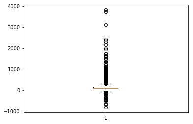

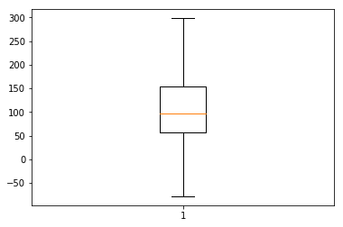

```
<function matplotlib.pyplot.hist(x, bins=None, range=None, density=None, weights=None, cumulative=False, bottom=None, histtype='bar', align='mid', orientation='vertical', rwidth=None, log=False, color=None, label=None, stacked=False, normed=None, *, data=None, **kwargs)>
```

```python
# Visualize revenue
# Note: removing the traditional definition of outliers would greatly skew the model as shown below
plt.boxplot(sales['SalesRevenue'])
plt.show()
plt.boxplot(sales['SalesRevenue'], showfliers=False)
plt.show()
plt.hist
```

```python
# Since we're looking for some targeted month information, let's aggregate by month
monthdf = sales.groupby(by = 'month').sum()
monthdf = monthdf.reset_index()
monthdf
```

|  | month | Store_ID | Fiscal_Qtr | dow | Hour | temp | SalesRevenue | afternoon | breakfast | dinner | ... | clear_night | cloudy | fog | partly_cloudy_day | partly_cloudy_night | rain | snow | wind | year | day |
| --- | --- | --- | --- | --- | --- | --- | --- | --- | --- | --- | --- | --- | --- | --- | --- | --- | --- | --- | --- | --- | --- |
| 0 | 1 | 189197 | 10797 | 41788 | 147806 | 540732.34 | 1012400.91 | 2508.0 | 2697.0 | 2934.0 | ... | 2013.0 | 227.0 | 180.0 | 994.0 | 372.0 | 831.0 | 23.0 | 58.0 | 21766578 | 175978 |
| 1 | 2 | 188883 | 10702 | 41293 | 145881 | 570659.15 | 1198876.71 | 2428.0 | 2785.0 | 2893.0 | ... | 1530.0 | 145.0 | 63.0 | 1319.0 | 348.0 | 799.0 | 30.0 | 98.0 | 21575072 | 157505 |
| 2 | 3 | 210039 | 13368 | 45733 | 163109 | 725458.76 | 1596609.20 | 2655.0 | 3087.0 | 3312.0 | ... | 1376.0 | 251.0 | 60.0 | 2112.0 | 275.0 | 819.0 | 0.0 | 61.0 | 24002230 | 189745 |
| 3 | 4 | 211902 | 23994 | 46953 | 164705 | 831498.41 | 1611902.77 | 2649.0 | 3109.0 | 3347.0 | ... | 780.0 | 180.0 | 15.0 | 2414.0 | 198.0 | 1338.0 | 0.0 | 127.0 | 24185407 | 187502 |
| 4 | 5 | 229631 | 25878 | 49809 | 177572 | 972116.11 | 1717376.44 | 2844.0 | 3380.0 | 3591.0 | ... | 382.0 | 104.0 | 109.0 | 2922.0 | 72.0 | 2019.0 | 0.0 | 1.0 | 26083731 | 206914 |
| 5 | 6 | 248544 | 28885 | 52299 | 185986 | 1100534.32 | 1761138.41 | 2955.0 | 3565.0 | 3754.0 | ... | 372.0 | 110.0 | 88.0 | 3398.0 | 105.0 | 3201.0 | 0.0 | 1.0 | 27319866 | 213458 |
| 6 | 7 | 191665 | 32967 | 43425 | 151059 | 925325.96 | 1435195.85 | 2420.0 | 2846.0 | 3025.0 | ... | 369.0 | 7.0 | 3.0 | 2611.0 | 40.0 | 2015.0 | 0.0 | 1.0 | 22149925 | 154574 |
| 7 | 8 | 139356 | 25977 | 33376 | 118935 | 718068.17 | 1079920.52 | 1903.0 | 2252.0 | 2412.0 | ... | 569.0 | 42.0 | 0.0 | 2377.0 | 80.0 | 922.0 | 0.0 | 0.0 | 17449893 | 140058 |
| 8 | 9 | 138874 | 26260 | 32356 | 114352 | 660152.42 | 977715.95 | 1872.0 | 2208.0 | 2305.0 | ... | 922.0 | 83.0 | 6.0 | 1823.0 | 129.0 | 728.0 | 0.0 | 0.0 | 16897903 | 130426 |
| 9 | 10 | 143360 | 34576 | 34060 | 118103 | 605424.63 | 934396.84 | 1944.0 | 2247.0 | 2382.0 | ... | 1320.0 | 96.0 | 7.0 | 957.0 | 86.0 | 365.0 | 0.0 | 13.0 | 17419876 | 138139 |
| 10 | 11 | 139232 | 33108 | 32023 | 112815 | 493177.42 | 766696.62 | 1886.0 | 2149.0 | 2231.0 | ... | 1770.0 | 88.0 | 9.0 | 636.0 | 226.0 | 563.0 | 0.0 | 36.0 | 16679965 | 125905 |
| 11 | 12 | 157216 | 31331 | 33823 | 121168 | 479732.04 | 776368.52 | 2030.0 | 2376.0 | 2363.0 | ... | 1603.0 | 241.0 | 181.0 | 882.0 | 322.0 | 1008.0 | 2.0 | 44.0 | 18026161 | 140342 |

12 rows × 23 columns

```
<BarContainer object of 12 artists>
```

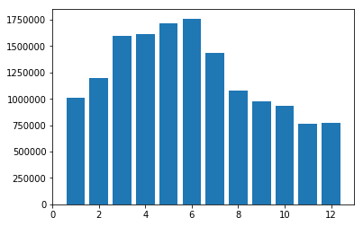

```python
plt.bar(x=monthdf['month'], height=monthdf['SalesRevenue'])
```

```python
# Deep copy avoids potential errors when running correlation
train_df = X_train.copy(deep=True)
train_df.head()
```

|  | Store_ID | Fiscal_Qtr | dow | Hour | temp | afternoon | breakfast | dinner | late_night | lunch | ... | cloudy | fog | partly_cloudy_day | partly_cloudy_night | rain | snow | wind | year | month | day |
| --- | --- | --- | --- | --- | --- | --- | --- | --- | --- | --- | --- | --- | --- | --- | --- | --- | --- | --- | --- | --- | --- |
| 125060 | 17 | 1 | 3 | 7 | 37.82 | 0 | 1 | 0 | 0 | 0 | ... | 0 | 0 | 0 | 0 | 0 | 0 | 0 | 2014 | 1 | 15 |
| 99386 | 16 | 1 | 4 | 15 | 46.76 | 1 | 0 | 0 | 0 | 0 | ... | 0 | 0 | 0 | 0 | 0 | 0 | 0 | 2015 | 2 | 26 |
| 28914 | 36 | 1 | 3 | 15 | 69.49 | 1 | 0 | 0 | 0 | 0 | ... | 0 | 0 | 0 | 0 | 0 | 0 | 0 | 2017 | 1 | 25 |
| 100162 | 17 | 1 | 1 | 14 | 37.40 | 1 | 0 | 0 | 0 | 0 | ... | 0 | 0 | 0 | 0 | 1 | 0 | 0 | 2015 | 2 | 16 |
| 4745 | 31 | 2 | 2 | 17 | 75.38 | 0 | 0 | 1 | 0 | 0 | ... | 0 | 0 | 0 | 0 | 1 | 0 | 0 | 2017 | 6 | 20 |

5 rows × 22 columns

```python
# Correlation Matrix - first view before modeling
train_df['SalesRevenue'] = y_train
corr_matrix = train_df.corr()
corr_matrix["SalesRevenue"].sort_values(ascending=False)
```

[output not shown]

```python
# Doing a quick peek at the previous day's data (most recent data in the dataset) to compare deltas
# Querying with filters 2017-07-14 at hour 12
yesterdataframe = sales.loc[(sales['year'] == 2017) & (sales['month'] == 7) & (sales['day'] == 14) & (sales['Hour'] == 12)]
yesterdataframe = yesterdataframe.drop(['Fiscal_Qtr','date','dow','Hour','afternoon','breakfast','dinner','cloudy','fog','partly_cloudy_day','partly_cloudy_night','rain','snow','wind','year','month','day','late_night','lunch','clear_night'], axis=1)
yesterdataframe.to_csv('store_results_20170714.csv')
yesterdataframe
```

[output not shown]

```python
# Understanding the dataset further - a call to action for potential time series analysis in the future
sales.hist(bins=50, figsize=(20,15))
plt.savefig('data_preview.png')
plt.show()
```

[output not shown]

```python
# SCATTER MATRIX TEST - TAKES TOO LONG FOR LITTLE INSIGHT
# scatter_matrix(sales[attributes], figsize=(12, 8))
```

```python
# This is where I originally scaled and transformed data using LinearRegression()
# Thankfully, there is no need to scale with RandomForestRegressor()
```

```python
# Modeling
model = RandomForestRegressor(n_estimators=200)
```

## 5. TRAIN MODEL

```python
# Train the models with the scaled data
# ESTIMATED runtime = 1 minute (8GB ram, 2.3 GHz i5)
model.fit(X_train, y_train.ravel()) # Ravel used to format array for fit() function
```

## 6. PREDICTION

```python
# create the predictions
predictions = model.predict(X_test)
```

```python
# manually display values and calculate residuals
delta = y_test.ravel() - predictions.ravel()
compare_df = pd.DataFrame({"Actual":y_test.ravel(), "Predictions": predictions.ravel(), "Residual":delta})
compare_df.head()
```

[output not shown]

```python
# Scatter of residuals
# NOTE: HEAVY MEMORY USAGE

plt.scatter(predictions, delta)
plt.hlines(y=0, xmin=y_test.min(), xmax=y_test.max())
plt.title("Residual Plot")
plt.savefig('residuals_plot.png')
plt.show()
```

[output not shown]

```python
# display the model score
MSE = mean_squared_error(y_test, predictions)
r2 = model.score(X_test, y_test)

print(f"MSE: {MSE}, R2: {r2}")
```

[output not shown]

# ANSWER 1: Top Predictors

*Requirement: Display the top 5 predictors*

```python
# create a dataframe of the importance features sorted
feature_names = X_train.columns
importances = sorted(zip(model.feature_importances_, feature_names), reverse=True)
importance_df = pd.DataFrame(importances)
importance_df = importance_df.rename(columns={0:"Importance",1:"Feature"})
importance_df.to_csv('deliverable_1_top_predictors.csv')
importance_df
```

[output not shown]

# ANSWER 2: Prediction for 2017-07-15 (aka 'tomorrow')

*Requirements restated:*

1. Predict total sales revenue for all 14 stores
2. on 2017-07-15 (assumes qtr = 3 and dow = 6)
3. during hour 12, (assumes lunch daypart)
4. assuming a clear day (hourlyweather dummy data set to 0 elsewhere)
5. and average temperature of 86 degrees.

```python
# Loop through stores and create a new test dataframe set based on the given parameters

Fiscal_Qtr = 3
dow = 6
Hour = 12
temp = 86
afternoon = 0
breakfast = 0
dinner = 0
late_night = 0
lunch = 1
clear_day = 1
clear_night = 0
cloudy = 0
fog = 0
partly_cloudy_day = 0
partly_cloudy_night = 0
rain = 0
snow = 0
wind = 0
year = 2017
month = 7
day = 15

stores = sales['Store_ID'].unique()
stores_data = []

for x in stores:
    record = [Fiscal_Qtr, dow, Hour, temp, afternoon, breakfast, dinner, late_night, lunch, clear_day, clear_night, cloudy, fog, partly_cloudy_day, partly_cloudy_night, rain, snow, wind, year, month, day]
    record.insert(0,x)
    stores_data.append(record)

keys = []
for i in X_train.keys():
    keys.append(i)

slalom_df = pd.DataFrame(stores_data)
for z in keys:
    slalom_df = slalom_df.rename(columns={
        0:keys[0],
        1:keys[1],
        2:keys[2],
        3:keys[3],
        4:keys[4],
        5:keys[5],
        6:keys[6],
        7:keys[7],
        8:keys[8],
        9:keys[9],
        10:keys[10],
        11:keys[11],
        12:keys[12],
        13:keys[13],
        14:keys[14],
        15:keys[15],
        16:keys[16],
        17:keys[17],
        18:keys[18],
        19:keys[19],
        20:keys[20],
        21:keys[21],
    })

slalom_df
```

[output not shown]

```python
# display the predictions in a dataframe from our model

slalom_predictions = model.predict(slalom_df)
pred_arr = []

z = 0
while z < len(stores):
    row = []
    row.append(stores[z])
    row.append(slalom_predictions[z])
    pred_arr.append(row)
    z = z + 1

slalom_predictions_df = pd.DataFrame(pred_arr)
print("Revenue prediction on 2017-07-15 (day 6) assuming a clear day, 86 degrees, and at hour 12")
slalom_predictions_df = slalom_predictions_df.rename(columns={0:"Store ID",1:"Sales Prediction"})
slalom_predictions_df.to_csv('deliverable_2_store_predictions.csv')
slalom_predictions_df
```

[output not shown]